# ILC Cell Line Encyclopedia (ICLE) Data Analysis

true June 26, 2026

- Associated Publication and Data Availability
- 1. Preparation
  - Setup Environment
  - Load All Data
- 2. Manuscript Figures
  - a. Multi-omic Characterization of ILC Cell Lines and Genomic Fidelity to Human ILC
    - SupFig 1: Genotypic Similarity With Public Datasets
    - Perform Molecular Subtyping
    - SupFig 2: RNA-seq Consensus Clustering
    - SupFig 3: RPPA Consensus Clustering
    - SupFig 4: DNAm Consensus Clustering
    - Figure 1B: Overview of Multiomic Subtypes
    - Figure 1C: SET Signature
    - Figure 1D: Multiomics Overview
    - Fig 1E: IGV Plot (Patient Tumors vs Cell Lines)
    - Figure 1F: Alteration Frequency Barplots (Patient Tumors vs Cell Lines)
    - SupFig 5: Key ILC vs NST Alterations (Patient Tumors)
    - SupFig 6: Alterations in Key Pathways (ICLE)
  - b. Recapitulation of the CDH1 Alteration Landscape in ILC Cell Line Models
    - Figure 2B: Novel SVs in CDH1
    - Figure 2C: Exonic Deletions in ICLE
    - Figure 2D: CDH1 Alterations in Local Recurrences and Distant Metastases (Patient Tumors)
    - Figure 2E: CDH1 Mutation Lollipop Plots (Patient Tumors vs Cell Lines)
    - Figure 2F: CDH1 Allele Frequency in Cell Lines
    - Figure 2G: CDH1 Alteration Type Frequencies (Patient Tumors vs Cell Lines)
    - Figure 2H: CDH1 Molecular Alteration Landscape (Patient Tumors vs Cell Lines)
  - c. Optical Genome Mapping Reveals Structural Variations, Chromothripsis and Functional Fusions
    - Figure 3A (left): ICLE Genomic Instability Metrics
    - Figure 3A (right): ICLE SV Type Distribution
    - Figure 3B: Chromosomal Topography of Translocation Breakpoints
    - Figure 3C: Chromothripsis Landscape
    - Figure 3D: OGM Circos Plots — BCK4, 600MPE, HCC2185, ZR7530
    - Figure 3E: Fusion Distribution (Patient Tumors vs Cell Lines)
    - Figure 3F: GOE and LOE Functional Fusions Circos
    - SupFig 8A: Mutation Count vs SV Count and SV Size
    - SupFig 8B: TMB vs SV Burden (With and Without Outliers)
    - SupFig 8C: SV Count per Chromosome
    - SupFig 8D: Somatic Mutation Count per Chromosome
    - SupFig 9: OGM Circos Plots
    - SupFig 10: Functional Fusions Landscape
  - d. Global Methylation Instability and Epigenetic Regulation of ILC Driver Genes
    - SupFig 11: DNAm Instability Score (DMI) by PAM50 Subtype and Histology
    - Figure 4A: DNAm Instability Score (DMI) by Specimen Type
    - Figure 4B: Consensus DNAm–mRNA Alterations (Patient Tumors and Cell Lines)
    - Figure 4C: Consensus DNAm-Regulated Genes
    - Figure 4D: Top Consensus DNAm-Regulated Genes — Expression and Methylation Barplots
  - e. Identification of ILC-Specific Gene Dependencies and Nomination of Druggable Targets
    - Figure 5A: ILC-Specific Dependency Analysis — Study Schematic
    - Figure 5B: Consensus ILC-Specific Differential Dependencies
    - SupFig 12: Consensus Differential Dependencies Heatmap
    - Figure 5C: KEGG Pathway Over-Representation in ILC-Specific Dependency Genes
    - Figure 5D: Pathway-Level Dependency Scores
    - Figure 5E: Druggable ILC Dependencies — Prioritized Therapeutic Targets
  - f. Integrative Multi-omic Benchmarking Framework for ILC Model Selection
    - Figure 6: CL–tumor Concordance / Molecular Resemblance Scores

# Associated Publication and Data Availability

This bioinformatics pipeline accompanies the manuscript: *“Multi-omic characterization of the ILC cell line encyclopedia (ICLE) defines new models for biomarker discovery and therapeutic exploration”*.

To reproduce all analyses, clone this GitHub repository and download the ICLE and external datasets from [Zenodo](https://zenodo.org/records/18686750). Extract the contents of each `.tar.gz` archive directly into the repository’s `1-Datasets/` folder, then follow the instructions in `2-Analysis/README.md`.

This R Markdown document orchestrates the complete multi-omics analysis pipeline for the ICLE project, from data loading through figure generation.

**`2-Analysis/` directory layout:**

- **`config.R`** – Defines project root and all path variables (`DIRS`, `FILES`). Must be sourced from `2-Analysis/`.
- **`requirements.R`** – Package installation and version checking for all dependencies.
- **`Helper_Scripts/`** – Contains data-loading modules and per-figure analysis scripts:
  - *Data loading* (`Data_Loading/`): scripts for loading annotations and data modalities (RPPA, RNA-seq, CNV, SNV, DNAm, SV, external datasets, GAM generation).
  - *Figure 1*: scripts 01, 02 (sources `03_Fig1C`), 04–07.
  - *Figure 2*: orchestrator `08_Fig2_CDH1_Alteration_Landscape_All.R` (sources `08_Fig2C` – `13_Fig2H`).
  - *Figure 3*: orchestrator `14_Fig3_SV_All.R` (sources `14_SupFig8`, 15–20; scripts 17–18 are sourced by 19–20).
  - *Figure 4:* script 21
  - *Figure 5:* script 22
  - *Figure 6*: script 23
- **`README.md`** – Environment setup, package installation, and step-by-step run instructions.

**Future Directions:**

A dedicated R package and interactive web application are in development to provide streamlined access to the cell line model scoring framework described in this study.

**Additional Notes:**

ICLE and integrated BRCA cell line datasets are available through an institutional [cBioPortal](https://cbioportal.crc.pitt.edu) instance:

- [ICLE Dataset](https://cbioportal.crc.pitt.edu/study/summary?id=ILC_Cell_Line_Encyclopedia) (N = 17 cell lines)
- [Integrated BRCA Cell Line Dataset](https://cbioportal.crc.pitt.edu/study/summary?id=BRCA_Cell_Line_Integrated) (ICLE integrated with public datasets, N = 56 cell lines)

Raw sequencing files are deposited at NCBI under [BioProject PRJNA1406296](https://www.ncbi.nlm.nih.gov/bioproject/PRJNA1406296). Processed data are deposited at [Zenodo](https://zenodo.org/records/18686750).

# 1. Preparation

## Setup Environment

Set these to `TRUE` to reduce console noise during knitting. Set to `FALSE` to show package startup messages and warnings.

```r
# Define Warning and Knitr parameters
SUPPRESS_PKG_MESSAGES <- TRUE   # FALSE = show package startup messages
SUPPRESS_WARNINGS <- TRUE       # FALSE = show warnings
SUPPRESS_FEATURE_SELECTION_PLOTS <- TRUE  # FALSE = show intermediate plots from FSbyMAD/FSbyVar
SUPPRESS_CONSENSUS_CLUSTER_PLOTS <- TRUE  # FALSE = show intermediate plots from ConsensusClusterPlus

knitr::opts_chunk$set(dev = "png", dpi = 300, fig.width = 6, fig.height = 4,
                      screenshot.force = FALSE, cache = FALSE)

# Set working directory
# setwd("/root/capsule/code/2-Analysis/")

# Install packages
source("requirements.R")
install_all_packages()
```

```
## ==============================================

## Installing ICLE Project Dependencies

## ==============================================

## All CRAN packages already installed.

## All Bioconductor packages already installed.

##
## ==============================================

## Package installation complete!

## ==============================================
```

```r
install_github_packages()
load_packages()
```

```
## Loading packages...

## All packages loaded successfully ✓

## [1] TRUE
```

```r
# load configuration
source("config.R")
```

```
## ===============================================
## ICLE Project Configuration Loaded
## ===============================================
## Project Root: /Users/oshah/Documents/ICLE
## Directories verified: TRUE
## Files verified: TRUE
## Random seed set: 123
## ===============================================
```

```r
# Load helper functions
suppressPackageStartupMessages(suppressWarnings(source(file.path(DIRS$scripts$helpers, "Helper_Functions.R"))))
```

## Load All Data

Loads all ICLE and external datasets into the R session via the modular `Data_Loading/` scripts.

```r
# Load all ICLE data using the master orchestrator
source(file.path(DIRS$scripts$helpers, "Data_Loading", "01_load_all_data.R"))

# Load all data (ICLE + external datasets)
load_all_icle_data(load_external = TRUE, verbose = TRUE)
```

```
## STEP 0/8: Cell Line Annotations already loaded (skipping)

## STEP 1/8: RPPA data already loaded (skipping)

## STEP 2/8: RNA-seq data already loaded (skipping)

## STEP 3/8: CNV data already loaded (all required objects present in GlobalEnv)

## STEP 4/8: Loading Single Nucleotide Variation (WES) Data...

## Loading SNV/mutation data...

## ═══════════════════════════════════════════════════════

##   SNV Data Preparation Pipeline

## ═══════════════════════════════════════════════════════

##

## Step 1/3: Filtering and merging MAF files...

## 'ICLE_Hg38.maf.gz' already exists — skipping MAF filtering.

##   ✓ MAF filtering and merging complete

## Step 2/3: Performing genome liftover to hg19...

## 'ICLE_Hg38_liftover.maf.gz' already exists — skipping liftover

##   ✓ Genome liftover complete

## Step 3/3: Integrating ICLE and CCLE MAFs...

##   ✓ MAF integration complete

##

## ═══════════════════════════════════════════════════════

```

[output cut: 57 more lines]

```
##   • CL_Annots           : 56 x 38

##   • BRCA_CL_RPPA        : 207 x 88

##   • BRCA_CL_EXP         : 35353 x 68

##   • BRCA_CL_GISTIC      : 23109 x 95

##   • BRCA_CL_DNAm        : 453001 x 49

##   • ICLE_SV             : 4320 x 36

##   • BRCA_CL_GAM         : 23738 x 67

## ═══════════════════════════════════════════════════════
```

# 2. Manuscript Figures

## a. Multi-omic Characterization of ILC Cell Lines and Genomic Fidelity to Human ILC

### SupFig 1: Genotypic Similarity With Public Datasets

Pairwise SNP-based genotype similarity heatmap confirming unique cell line identities and verifying the absence of cross-contamination between ICLE and the Marcotte et al. panel.

```r
source(file.path(DIRS$scripts$helpers, "01_SupFig1_Genotype_Similarity.R"), chdir = TRUE)
```

```
## ═══════════════════════════════════════════════════════

##   Supplementary Figure 1: Genotype Similarity Analysis

## ═══════════════════════════════════════════════════════

##   Step 1/4: Loading and merging genotype data...

##   ✓ Genotype data merged: 692032 SNPs x 95 samples

##   Step 2/4: Converting genotype calls to integers...

##   ✓ Genotype calls converted

##   Step 3/4: Computing genotypic similarity matrix...

##   ✓ Similarity matrix computed

##   Step 4/4: Generating genotypic similarity heatmap...

##   ✓ Heatmap generated

## ═══════════════════════════════════════════════════════

##   Genotype Similarity Analysis Complete

## ═══════════════════════════════════════════════════════
```

```r
pdf(file = file.path(DIRS$results, "SupFig1_Genotype_Similarity.pdf"), width = 8, height = 6)
  draw(supFig_1, merge_legends = TRUE)
dev.off()
```

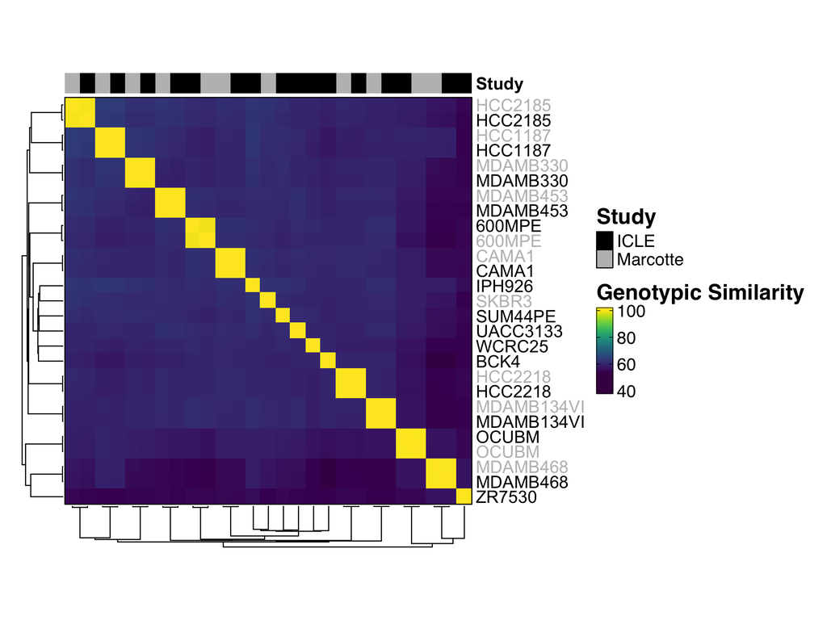

```r
draw(supFig_1, merge_legends = TRUE)
```

### Perform Molecular Subtyping

Performs all molecular subtyping and produces SupFigs 2–4 (Clustering heatmaps), Fig 1B (Sankey), and Fig 1C (SET heatmap) in one orchestrator script. Three independent approaches are used:

1. **Intrinsic subtyping** — multi-algorithm consensus using BreastSubtypeR (PAM50, SCMGENE, SSP, AIMS, GGI); majority-vote “TopCall” assignment.
2. **Data-driven multi-omic consensus clustering** — ConsensusClusterPlus on the top 6,000 MAD-variable genes (RNA), top 50 variable proteins (RPPA), and 6,000 variable probes (DNAm), each yielding an independent cluster solution consolidated into four core subtypes (Luminal, Luminal/HER2, HER2-enriched, Basal).
3. **SET signature** — endocrine therapy sensitivity inferred from published SET ER+/ER− gene modules (Symmans et al. 2010).

```r
source(file.path(DIRS$scripts$helpers, "02_Fig1_SupFig2_3_4_Molecular_Subtyping.R"), chdir = TRUE)
```

```
##
##   ── Step 1/5: molecular subtyping pipeline ──

## ═══════════════════════════════════════════════════════

##   Molecular Subtyping Pipeline

## ═══════════════════════════════════════════════════════

##   Step 1/7: Calculating ER status...

##   ✓ ER status calculated for 56 samples

##
##   Step 2/7: Calculating HER2 status...

##   ✓ HER2 status calculated for 56 samples

##
##   Step 3/7: Running Intrinsic Molecular Subtyping subtyping with BreastSubtypeR...

##   ✓ Intrinsic Molecular Subtyping subtyping complete

##
##   Step 4/7: Running mRNA consensus clustering...

##   ✓ mRNA clustering complete

##
##   Step 5/7: Running RPPA consensus clustering...

##   ✓ RPPA clustering complete

##
##   Step 6/7: Running DNAm consensus clustering...

##   ✓ DNAm clustering complete

##
##   Step 7/7: Updating annotations and saving results...
```

[output cut: 47 more lines]

```
##   Step 2/4: Calculating SET scores...

##   ✓ SET scores calculated for 68 samples

##   Step 4/4: Creating SET signature heatmaps...

##   ✓ SET score heatmap created

##   ✓ Heatmaps created and combined

## ═══════════════════════════════════════════════════════

##   MOLECULAR SUBTYPING COMPLETE

## ═══════════════════════════════════════════════════════
```

### SupFig 2: RNA-seq Consensus Clustering

Heatmap showing consensus clustering solution for top variable RNA features in integrated BRCA dataset. Heatmap annotations include multi-algorithm intrinsic molecular subtype (IMS) top calls, ER+ gene module scores and HER2 mRNA levels.

```r
pdf(file.path(DIRS$results_sub$molecular_subtyping, "SupFig2A_mRNA_subtypes.pdf"), width = 10, height = 8)
draw(mRNA_sim_HT, merge_legends = TRUE, heatmap_legend_side = "right")
dev.off()
```

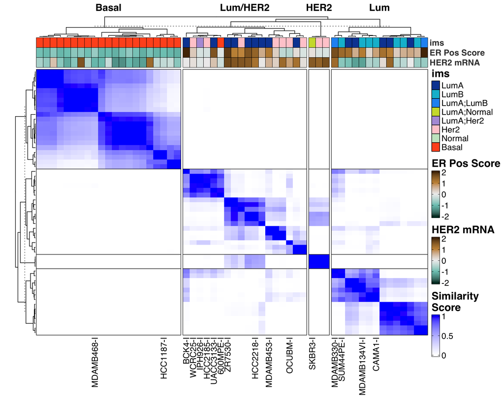

```r
draw(mRNA_sim_HT, merge_legends = TRUE, heatmap_legend_side = "right")
```

PCA plot of top variable RNA features showing cell clustering/similarity annotated by molecular subtypes

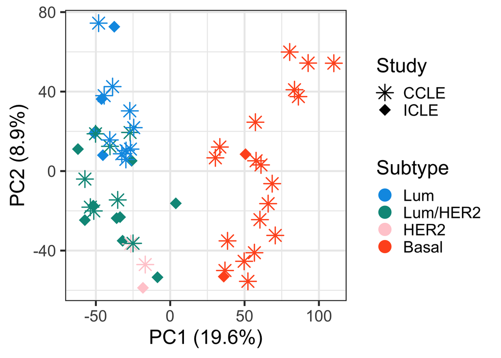

```r
ggsave(file.path(DIRS$results_sub$molecular_subtyping, "SupFig2B_mRNA_pca_subtypes.pdf"), supfig2b_mRNA_pca, width = 7, height = 5)
supfig2b_mRNA_pca
```

Sankey plot showing agreement between RNA molecular subtypes and (IMS) top calls

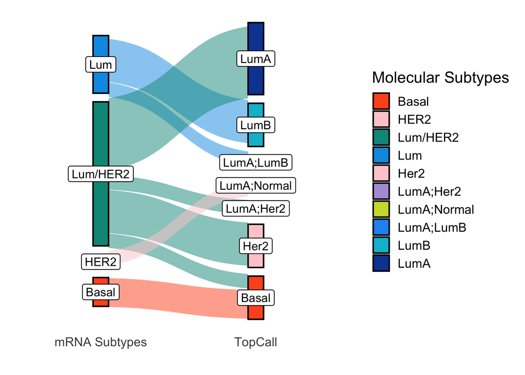

```r
ggsave(file.path(DIRS$results_sub$molecular_subtyping, "SupFig2C_RNA_ims.pdf"), rna_ims, width = 7, height = 5)
rna_ims
```

### SupFig 3: RPPA Consensus Clustering

```r
pdf(file.path(DIRS$results_sub$molecular_subtyping, "SupFig3A_RPPA_subtypes.pdf"), width = 10, height = 8)
draw(rppa_sim_HT, merge_legends = TRUE, heatmap_legend_side = "right")
dev.off()
```

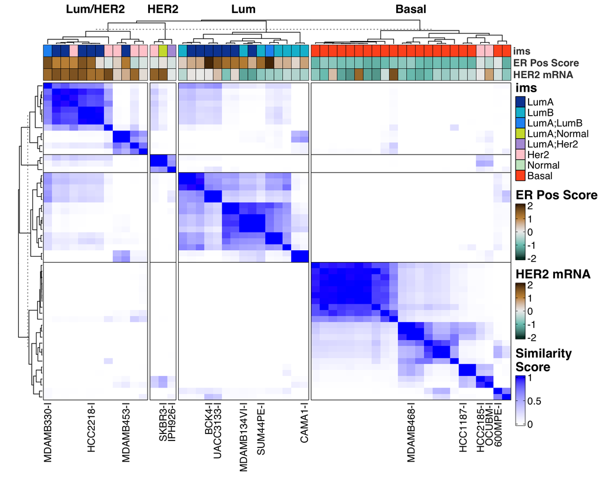

```r
draw(rppa_sim_HT, merge_legends = TRUE, heatmap_legend_side = "right")
```

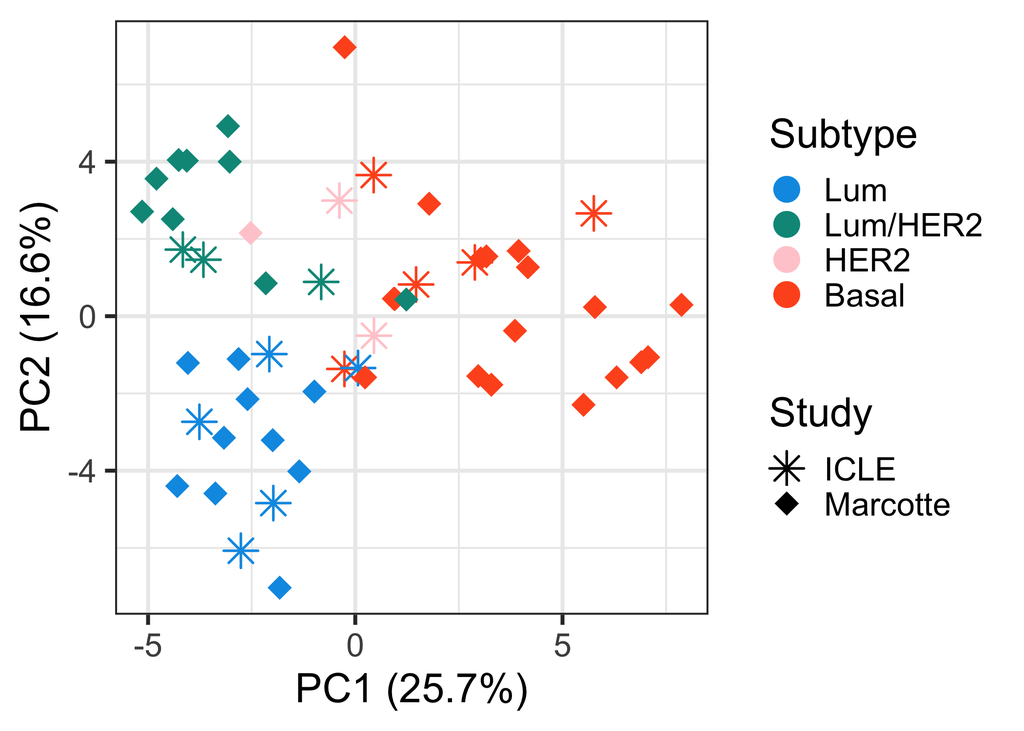

```r
ggsave(file.path(DIRS$results_sub$molecular_subtyping, "SupFig3B_RPPA_pca_subtypes.pdf"), supfig3b_rppa_pca, width = 7, height = 5)
supfig3b_rppa_pca
```

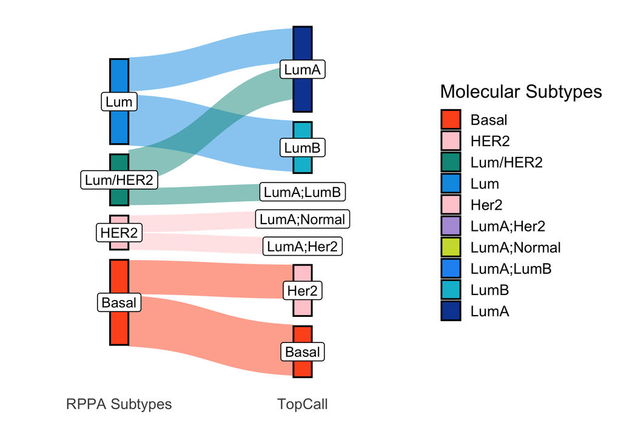

```r
ggsave(file.path(DIRS$results_sub$molecular_subtyping, "SupFig3C_RPPA_ims.pdf"), rppa_sankey, width = 7, height = 5)
rppa_sankey
```

### SupFig 4: DNAm Consensus Clustering

```r
pdf(file.path(DIRS$results_sub$molecular_subtyping, "SupFig4A_DNAm_subtypes.pdf"), width = 10, height = 8)
draw(dnam_sim_HT, merge_legends = TRUE, heatmap_legend_side = "right")
dev.off()
```

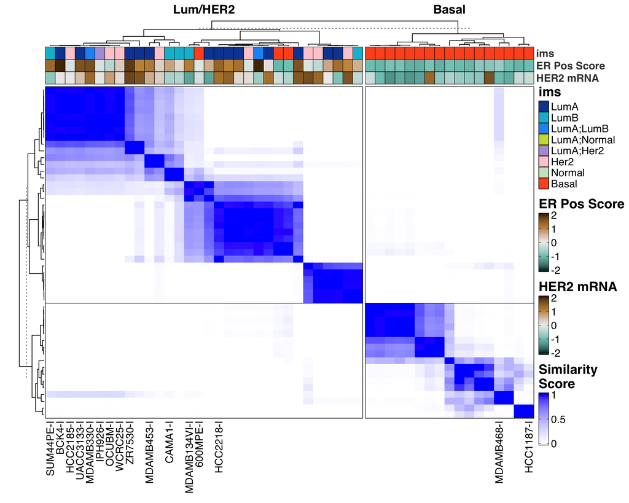

```r
draw(dnam_sim_HT, merge_legends = TRUE, heatmap_legend_side = "right")
```

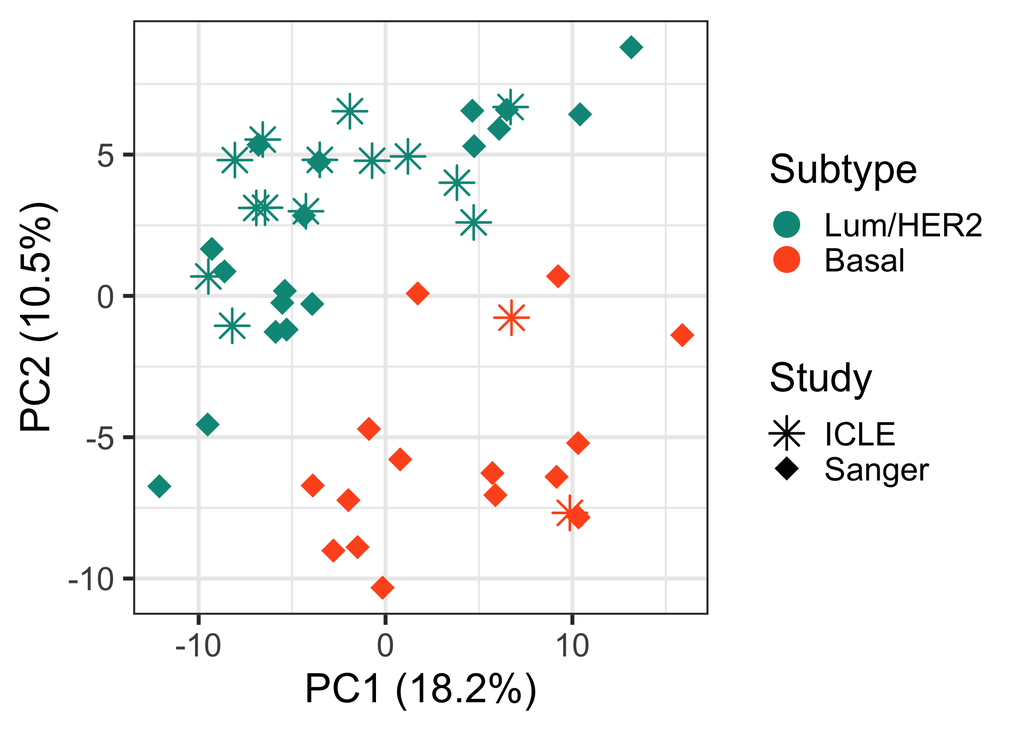

```r
ggsave(file.path(DIRS$results_sub$molecular_subtyping, "SupFig4B_DNAm_pca_subtypes.pdf"), supfig4b_dnam_pca, width = 7, height = 5)
supfig4b_dnam_pca
```

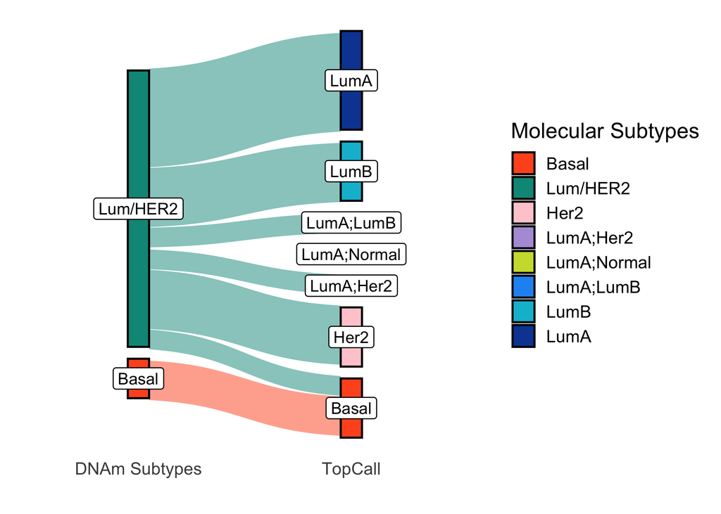

```r
ggsave(file.path(DIRS$results_sub$molecular_subtyping, "SupFig4C_DNAm_ims.pdf"), dnam_sankey, width = 7, height = 5)
dnam_sankey
```

### Figure 1B: Overview of Multiomic Subtypes

Sankey/alluvial diagram showing agreement across the three data-driven molecular subtype assignments (RNA, RPPA, DNAm).

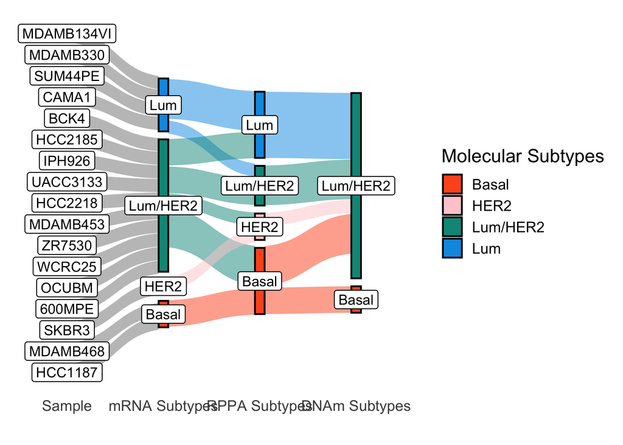

```r
ggsave(file.path(DIRS$results_sub$molecular_subtyping, "Fig1B_MolecularSubtypes.pdf"), fig1b_sankey, width = 7, height = 5)

fig1b_sankey
```

### Figure 1C: SET Signature

```r
pdf(file.path(DIRS$results_sub$molecular_subtyping, "Fig1C_SET_Signature.pdf"), width = 8, height = 6)
  draw(fig1c_setheatmap, merge_legends = TRUE)
dev.off()
```

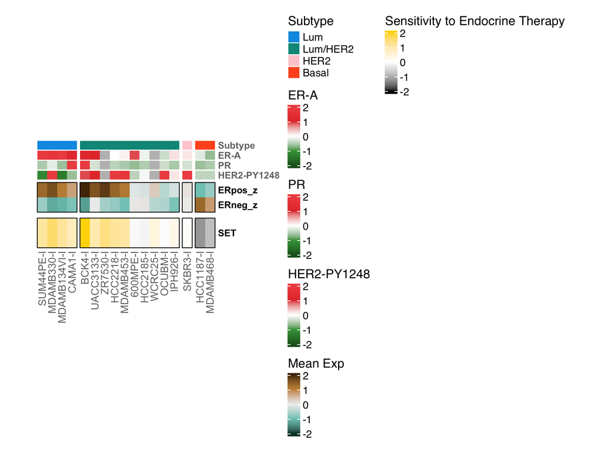

```r
draw(fig1c_setheatmap, merge_legends = TRUE)
```

### Figure 1D: Multiomics Overview

Comprehensive multi-omic overview heatmap summarising key genomic, transcriptomic, proteomic, and epigenetic features of ICLE cell lines. Features include ER/HER2 status, molecular subtypes, copy number alterations, somatic mutations and top variable RPPA/RNA/DNAm features.

```r
source(file.path(DIRS$scripts$helpers, "04_Fig1D_Multiomics_Overview.R"), chdir = T)
```

```
##
## ========================================

## Figure 1D: Multiomics Overview

## ========================================

##   Step 1/6: Loading additional genomic metrics...

##   ✓ Saved Genomic Instability Metrics to File/Users/oshah/Documents/ICLE/3-Results/Genomic_Instability_Metrics.tsv

##   ✓ Metrics loaded

##   Step 2/6: Preparing genetic alteration matrix...

##   ✓ Alteration matrix prepared: 9 genes x 17 samples

##   Step 3/6: Selecting top variable features...

##   ✓ RNA: 6000 genes selected

##   ✓ RPPA: 50 proteins selected

##   ✓ DNAm: 5913 probes selected

##
##   Step 4/6: Creating annotations...

##   ✓ Top annotation created

##
##   Step 5/6: Creating individual heatmaps...

##   ✓ Alteration heatmap created

##   ✓ RPPA heatmap created

##   ✓ RNA heatmap created

##   ✓ DNAm heatmap created

##
## ========================================

## Figure 1D Completed

## ========================================
```

```r
pdf(file.path(DIRS$results, "Fig1D_Multiome_Overview.pdf"), width = 6, height = 8)
  draw(fig1d_multiomics_overview, merge_legends = TRUE, annotation_legend_side = "right", heatmap_legend_side = "right")
dev.off()
```

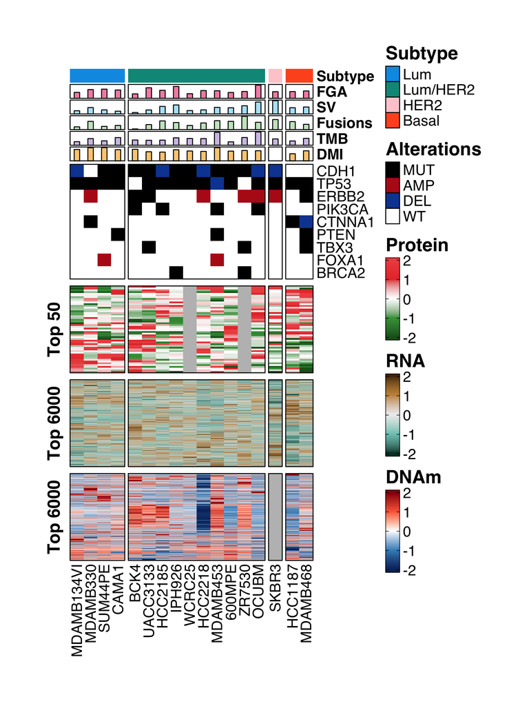

```r
fig1d_multiomics_overview
```

### Fig 1E: IGV Plot (Patient Tumors vs Cell Lines)

Prepares copy number segmentation files (log R ratio) per ICLE molecular subtype for genome-wide CN visualization in the Integrative Genomics Viewer (IGV). TCGA primary ILC (n = 127) and MSK metastatic ILC (n = 202) segment files are also subsetted and exported. These files are loaded directly into IGV to produce figure 1E subpanels.

```r
# prepare primary ILC patient tumor CN segments
TCGA_BRCA_CN_SEG <- read.delim(file.path(DIRS$external$tcga, "CN", "TCGA_logRR_DNAcopy.seg"))
TCGA_BRCA_CN_SEG$ID <- substr(TCGA_BRCA_CN_SEG$ID, 1, 15)
ILC_cases <- subset(TCGA_Annots, `Final Pathology` == "ILC")$Case.ID
ILC_seg <- subset(TCGA_BRCA_CN_SEG, ID %in% ILC_cases)
write.table(ILC_seg, file = file.path(DIRS$external$tcga, "CN", "TCGA_logRR_ILC_127.seg"), row.names = FALSE, quote = FALSE, sep = "\t")

# prepare metastatic ILC patient tumor CN segments
MSK_BRCA_CN_SEG <- read.delim(file.path(DIRS$external$msk, "CN", "MSK_BRCA_CN.seg"))
ILC_met_cases <- subset(MSK_Annots, ONCOTREE_CODE == "ILC")$SAMPLE_ID
ILC_met_seg <- subset(MSK_BRCA_CN_SEG, ID %in% ILC_met_cases)
write.table(ILC_met_seg, file = file.path(DIRS$external$msk, "MSK_CN_ILC_202.seg"), row.names = FALSE, quote = FALSE, sep = "\t")

# prepare ICLE CN segments by subtype
ICLE_cells <- subset(CL_Annots, Study == "ICLE")
ICLE_cells <- split(ICLE_cells$Name, ICLE_cells$`mRNA Subtypes`)
ICLE_cells$HER2 = "SKBR3-M" # borrow information on SKRB3 from Marcotte
ICLE_cells$Other <- c(ICLE_cells$HER2, ICLE_cells$Basal)
ICLE_cells <- ICLE_cells[-c(3,4)]

BRCA_CL_CN_SEG <- read.delim(FILES$cnv_seg)

BRCA_CL_CN_SEG_subtype <- sapply(ICLE_cells, FUN = function(x){
  subset(BRCA_CL_CN_SEG, ID %in% x)
}, simplify = F)

sapply(names(BRCA_CL_CN_SEG_subtype), FUN = function(x){
  seg = BRCA_CL_CN_SEG_subtype[[x]]
  x = gsub("[//]", "_", x)
  write.table(seg, file = file.path(DIRS$icle$cytosnp, "3_Segmentation", paste0(x, "_ICLE_CL_LogRR_DNACopy.seg")), row.names = FALSE, quote = FALSE, sep = "\t")
})
```

```
## $Lum
## NULL
##
## $`Lum/HER2`
## NULL
##
## $Other
## NULL
```

### Figure 1F: Alteration Frequency Barplots (Patient Tumors vs Cell Lines)

Compares alteration frequencies of ESMO ESCAT-scored actionable genes in luminal ICLE cell lines versus TCGA primary ILC and MSK metastatic ILC patient tumors. Differences in alteration frequency between groups are assessed by two-proportion z-test.

```r
suppressWarnings(source(file.path(DIRS$scripts$helpers, "05_Fig1F_Alteration_barplots.R")))
```

```
##
## ========================================

## Figure 1F: Alteration Barplots

## ========================================

##   Step 1/5: Defining gene sets...

##   ✓ Gene sets defined:

##     - ILC genes: 6

##     - NST genes: 7

##     - ESCAT genes: 25

##     - Total unique genes: 32

##   Step 2/5: Calculating alteration frequencies...

##     Processing Cell Lines...

##       - Samples: 14

##       - Altered genes: 25

##     Processing Primary Tumors...

##       - Samples: 126

##       - Altered genes: 30

##     Processing Metastatic Tumors...

##       - Samples: 194

##       - Altered genes: 31

##
```

[output cut: 9 more lines]

```
##   Step 4/5: Creating alteration barplot...

##   ✓ Barplot created

##   Step 5/5: Performing statistical tests...

##   ✓ Statistical tests completed

##   Saving results p-values plots...

##   ✓ P-values (numeric) saved: /Users/oshah/Documents/ICLE/3-Results/Molecular_Resemblance/Fig1F_Alteration_Barplot_pval.html

##   ✓ P-values (notation) saved: /Users/oshah/Documents/ICLE/3-Results/Molecular_Resemblance/Fig1F_Alteration_Barplot_pval_nt.html

##   ✓ Figure 1F complete
```

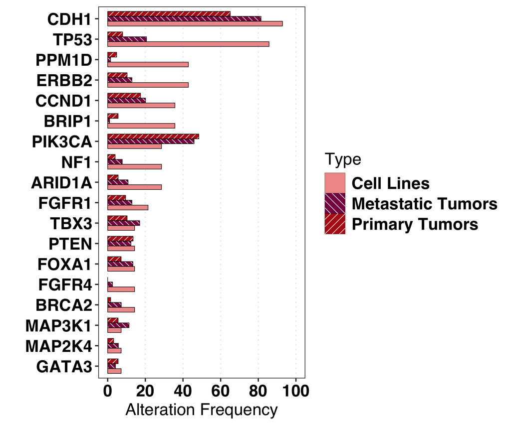

```r
output_file <- file.path(DIRS$results, "Molecular_Resemblance", "Fig1F_Alteration_Barplot.pdf")
ggsave(filename = output_file, fig1f_alteration_barplot, width = 6, height = 5)

fig1f_alteration_barplot
```

### SupFig 5: Key ILC vs NST Alterations (Patient Tumors)

Barplot comparing the frequencies of key somatic alterations in ILC versus NST primary and metastatic breast cancer patient tumors. Statistical comparisons performed using a two-proportion z-test.

```r
source(file.path(DIRS$scripts$helpers, "06_SupFig5_ILC_NST_Alterations.R"), chdir = TRUE)
```

```
##
## ========================================

## SupFig 5: ILC vs NST alteration frequencies (LumA tumors)

## ========================================

## Specs: 28 rows, 14 genes

##   ✓ SupFig 5 complete (supfigs5_tumor_alterations, freq_tbl assigned).
```

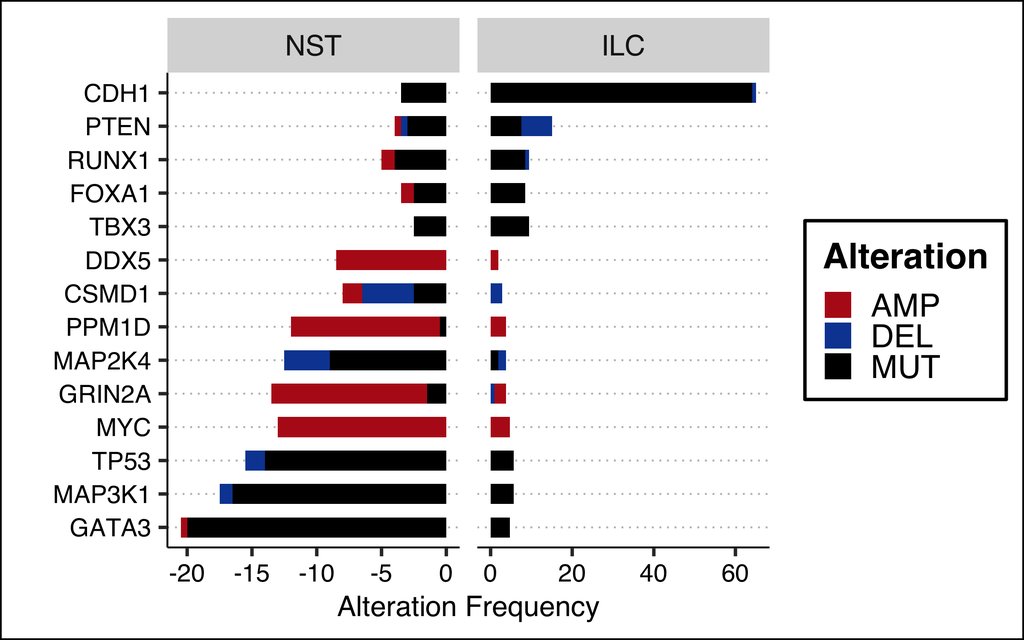

```r
ggsave(file.path(DIRS$results, "SupFig5_BRCA_Tumor_Top_Alterations.pdf"), supfigs5_tumor_alterations, width = 8, height = 5)

write.table(freq_tbl, file.path(DIRS$results, "SupFig5_BRCA_Tumor_Top_Alterations.tsv"),  # source data for SupFig 5
            sep = "\t", quote = FALSE, row.names = FALSE)

supfigs5_tumor_alterations
```

### SupFig 6: Alterations in Key Pathways (ICLE)

```r
source(file.path(DIRS$scripts$helpers, "07_SupFig6_Pathway_Alterations.R"), chdir = TRUE)
```

```
##
## ========================================

## SupFig 6: Pathway alterations (ICLE)

## ========================================

##   ✓ SupFig 6 complete (SupFigS6, pathway_alt_mat assigned).
```

```r
pdf(file.path(DIRS$results, "SupFig6_Pathway_Alterations.pdf"), width = 7.5, height = 8)
draw(SupFigS6, merge_legends = TRUE)
dev.off()
```

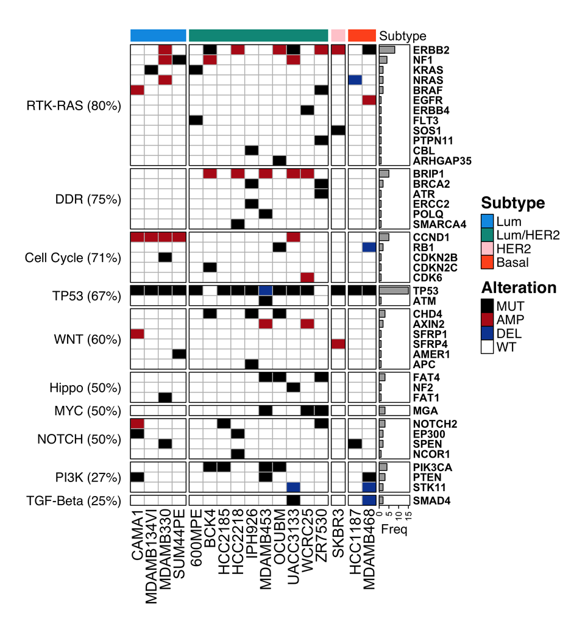

```r
write.table(pathway_alt_mat, file.path(DIRS$results, "SupFig6_Pathway_Alterations.tsv"),  # source data for SupFig 6
            sep = "\t", quote = FALSE, col.names = NA)

draw(SupFigS6, merge_legends = TRUE)
```

## b. Recapitulation of the CDH1 Alteration Landscape in ILC Cell Line Models

### Figure 2B: Novel SVs in CDH1

Structural variant visualizations for novel *CDH1* rearrangements detected by Bionano OGM. These figures are generated externally by loading the filtered SV files into Bionano Access (v1.7) software.

```r
# Visualizations generated using Bionano Access software by loading SV files
```

Runs the full CDH1 alteration analysis pipeline (Figs 2C–2H) via orchestrator script `08_Fig2_CDH1_Alteration_Landscape_All.R`, which sources sub-scripts 08_Fig2C through 13_Fig2H in order. Performs analysis and generates visualizations of: (i) exonic deletions in *CDH1* locus using WES read coverage, (ii) *CDH1* alteration frequency comparisons in FMI local and distant metastases, (iii) *CDH1* biallelic inactivation events in ILC vs NST tumors and cell lines, (iv) multi-omic overview of *CDH1* alteration landscape.

```r
source(file.path(DIRS$scripts$helpers, "08_Fig2_CDH1_Alteration_Landscape_All.R"), chdir = TRUE)
```

```
##
## ========================================

## Figure 2C: CDH1 Exonic Deletion Analysis

## ========================================

##   Loading WES CDH1 read counts...

##   Found 19 WES samples

##   ✓ Loaded read counts for 19 samples

##   Generating CDH1 deletion heatmap...

##   ✓ Heatmap generated with 16 exons and 5 samples

##   ✓ CDH1 exonic deletion analysis complete (fig2c_cdh1_exonic_del_heatmap assigned).

##
## ========================================

## Figure 2D: FMI CDH1 alterations (Local vs Distant)

## ========================================

##   ✓ Fig 2D complete (fig2d_fmi_alts, fig2d_fmi_alts_tbl, fig2d_fmi_alts_tbl_pval assigned).

##
## ========================================

## Figure 2E: CDH1 Protein Paint query

## ========================================

##   ✓ Saved Fig2E_CellLines_CDH1_Mutations_Protein_Paint_Query.tsv

##   ✓ Saved Fig2E_TCGA_CDH1_Mutations_Protein_Paint_Query.tsv

##
```

[output cut: 16 more lines]

```

##
## ========================================

## Figure 2H: CDH1 alteration landscape

## ========================================

##   ✓ Fig 2H complete (fig2h_tcga, fig2h_cl, TCGA_CDH1_df, CL_CDH1_df assigned).

## ═══════════════════════════════════════════════════════

##   Figure 2C-H complete

## ═══════════════════════════════════════════════════════
```

### Figure 2C: Exonic Deletions in ICLE

```r
pdf(file.path(DIRS$results_sub$cdh1, "Fig2C_CDH1_Exonic_Deletions_ICLE.pdf"), width = 4, height = 4.5)
draw(fig2c_cdh1_exonic_del_heatmap)
dev.off()
```

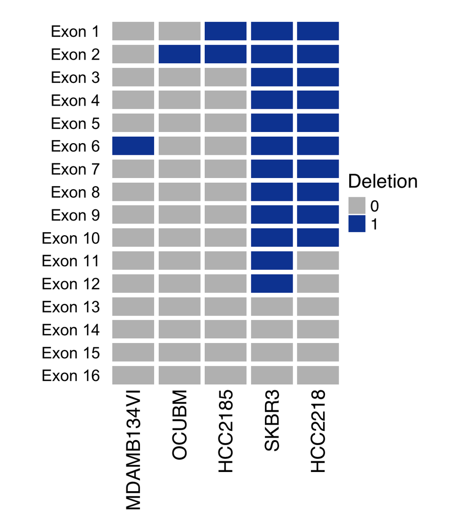

```r
draw(fig2c_cdh1_exonic_del_heatmap)
```

### Figure 2D: CDH1 Alterations in Local Recurrences and Distant Metastases (Patient Tumors)

Barplot comparing the frequency of *CDH1* structural rearrangements and copy number deletions in ILC versus NST breast cancers across local recurrence and distant metastasis groups in the FMI clinical cohort. Enrichment statistics computed by Chi-square exact test, restricted to cases without co-occurring *CDH1* point mutations or copy number gains.

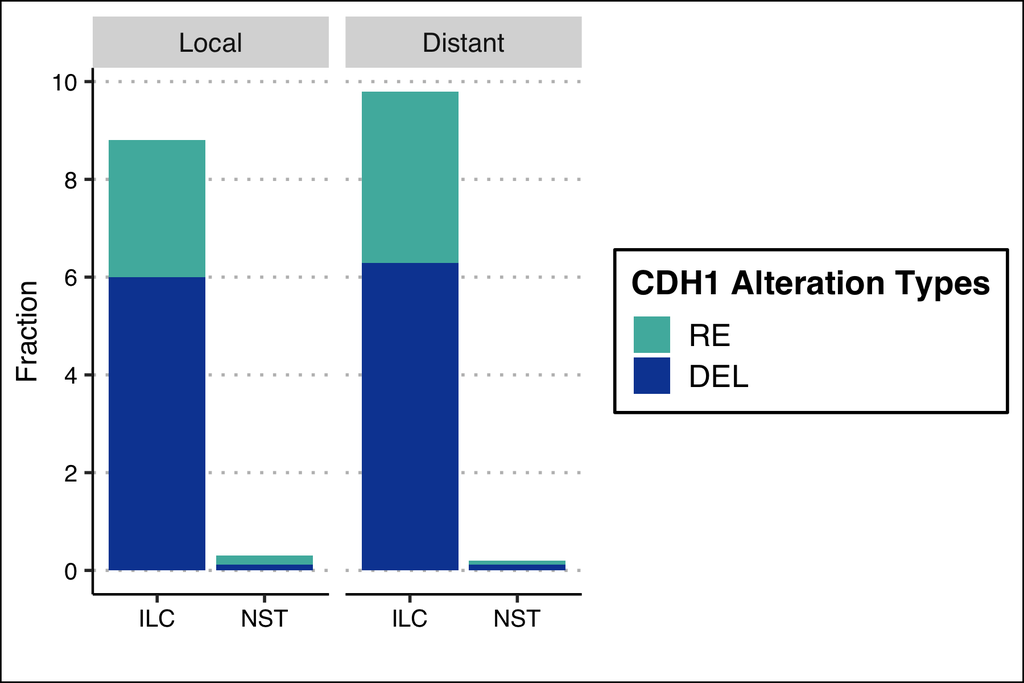

```r
ggsave(file.path(DIRS$results_sub$cdh1, "Fig2D_FMI_CDH1_Alterations_Barplot.pdf"), fig2d_fmi_alts, width = 6, height = 4)
gt::gtsave(gt::gt(fig2d_fmi_alts_tbl), file.path(DIRS$results_sub$cdh1, "Fig2D_FMI_CDH1_Alterations_Table.html"))
gt::gtsave(gt::gt(fig2d_fmi_alts_tbl_pval) %>%
               gt::cols_width(starts_with("local") ~ px(100),starts_with("distant") ~ px(100)) %>%
             gt::tab_options(table.width = px(600), column_labels.font.size = px(10)),
           file.path(DIRS$results_sub$cdh1, "Fig2D_FMI_CDH1_Alterations_ILCvsNST_Event_pval.html"))

fig2d_fmi_alts
```

### Figure 2E: CDH1 Mutation Lollipop Plots (Patient Tumors vs Cell Lines)

*CDH1* protein domain lollipop plot overlaying mutation positions across TCGA primary breast cancer tumors and integrated BRCA cell lines generated using the ProteinPaint web tool (Zhou et al. 2016; https://proteinpaint.stjude.org/).

```r
# queries files (Fig2E_TCGA_CDH1_Mutations_Protein_Paint_Query.tsv & Fig2E_CellLines_CDH1_Mutations_Protein_Paint_Query.tsv) plotted using https://proteinpaint.stjude.org/
```

### Figure 2F: CDH1 Allele Frequency in Cell Lines

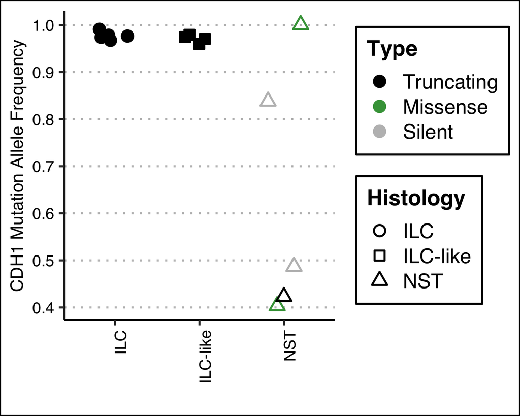

```r
ggsave(file.path(DIRS$results_sub$cdh1, "Fig2F_CL_CDH1_AF_Barplot_histology_shape.pdf"), fig2f_cdh1_af, width = 4.5, height = 4)

fig2f_cdh1_af
```

### Figure 2G: CDH1 Alteration Type Frequencies (Patient Tumors vs Cell Lines)

Side-by-side barplots comparing the frequency of *CDH1* alteration categories — point mutation, LOH, biallelic event (MUT+LOH), dual deletion — between integrated BRCA cell lines and TCGA primary BRCA tumors, stratified by ILC vs NST. Enrichment of biallelic events in ILC assessed by Chi-square test. Accompanying tables report per-event p-values.

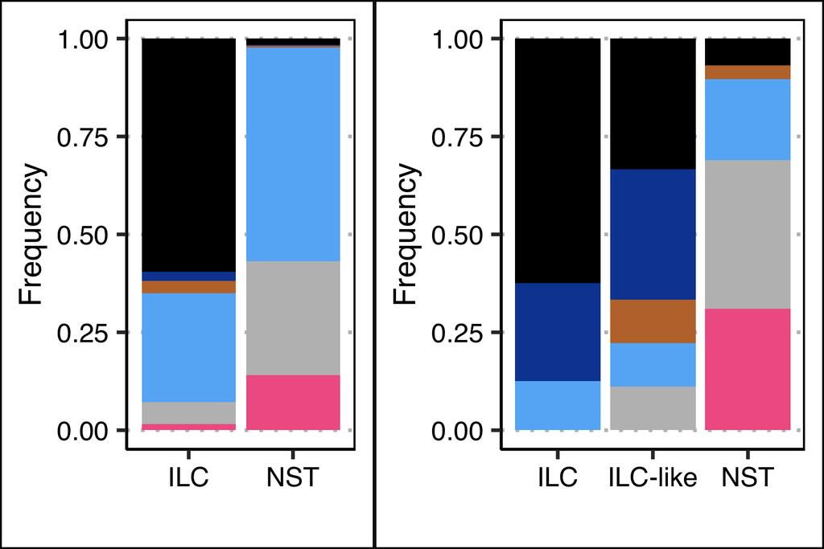

```r
ggsave(file.path(DIRS$results_sub$cdh1, "Fig2G_CL_CDH1_Alt_barplot.pdf"), fig2g_cl_cdh1_alts, width = 5, height = 5)
ggsave(file.path(DIRS$results_sub$cdh1, "Fig2G_TCGA_CDH1_Alt_barplot.pdf"), fig2g_tcga_cdh1_alts, width = 4, height = 5)
suppressMessages({
  gt::gtsave(gt::gt(fig2g_cl_cdh1_alts_tbl), file.path(DIRS$results_sub$cdh1, "Fig2G_CL_CDH1_Alterations_Table.html"))
  gt::gtsave(gt::gt(fig2g_cl_cdh1_alts_tbl_pval), file.path(DIRS$results_sub$cdh1, "Fig2G_CL_CDH1_Alterations_ILCvsNST_Event_pval.html"))
  gt::gtsave(gt::gt(fig2g_tcga_cdh1_alts_tbl), file.path(DIRS$results_sub$cdh1, "Fig2G_TCGA_CDH1_Alterations_Table.html"))
  gt::gtsave(gt::gt(fig2g_tcga_cdh1_alts_tbl_pval), file.path(DIRS$results_sub$cdh1, "Fig2G_TCGA_CDH1_Alterations_ILCvsNST_Event_pval.html"))
})

ggarrange(plotlist = list(fig2g_tcga_cdh1_alts, fig2g_cl_cdh1_alts), widths = c(0.5, 0.6))
```

### Figure 2H: CDH1 Molecular Alteration Landscape (Patient Tumors vs Cell Lines)

Overview of multi-omic *CDH1* alteration landscape heatmaps in ILC vs NST in Patient tumors and cell lines.

```r
write.table(TCGA_CDH1_df, file.path(DIRS$results_sub$cdh1, "Fig2H_TCGA_CDH1_Alteration_Landscape.tsv"), sep = "\t", row.names = FALSE)  # → Supplementary Table S10 (TCGA)
write.table(CL_CDH1_df, file.path(DIRS$results_sub$cdh1, "Fig2H_CellLines_CDH1_Alteration_Landscape.tsv"), sep = "\t", row.names = FALSE)   # → Supplementary Table S10 (cell lines)

pdf(file.path(DIRS$results_sub$cdh1, "Fig2H_TCGA_CDH1_Alteration_Heatmap.pdf"), width = 8, height = 10)
  draw(fig2h_tcga, merge_legends = TRUE)
dev.off()
```

```r
pdf(file.path(DIRS$results_sub$cdh1, "Fig2H_CellLine_CDH1_Alteration_Heatmap.pdf"), width = 8, height = 10)
  draw(fig2h_cl, merge_legends = TRUE)
dev.off()
```

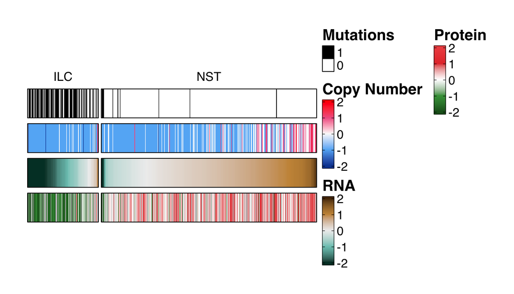

```r
draw(fig2h_tcga, merge_legends = TRUE)
```

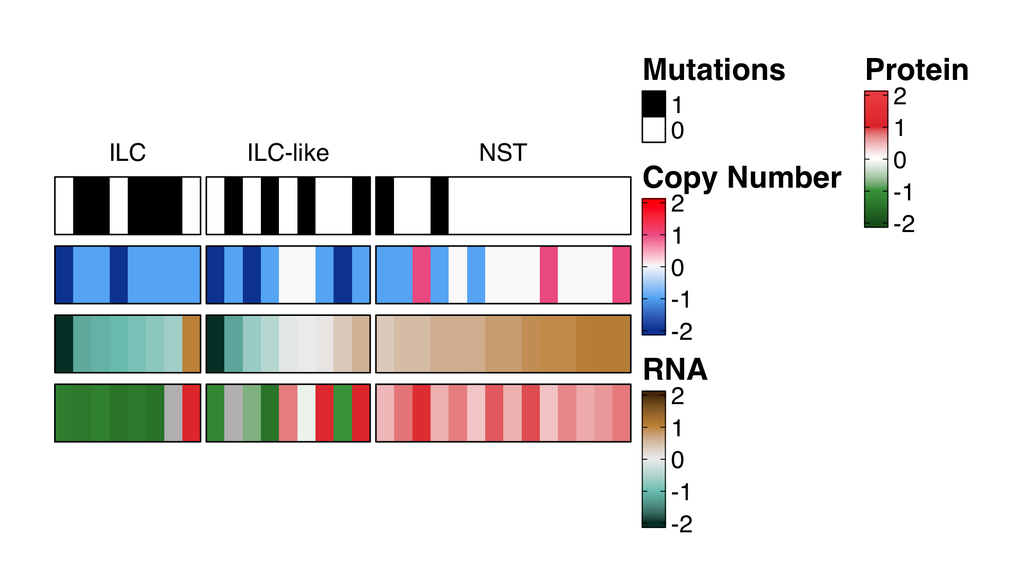

```r
draw(fig2h_cl, merge_legends = TRUE)
```

## c. Optical Genome Mapping Reveals Structural Variations, Chromothripsis and Functional Fusions

Runs all Figure 3 and SupFig 8–10 scripts in order via orchestrator `14_Fig3_SV_All.R`. This section characterises the structural variant (SV) landscape of ICLE cell lines profiled by Bionano Optical Genome Mapping (OGM; resolution ≥5 kb). Includes: TMB and SV burden metrics (SupFig 8), genome-wide SV distribution and genomic instability metrics (Fig 3A), translocation breakpoint topography (Fig 3B), chromothripsis detection using ShatterSeek (Fig 3C), circos plot generation (Fig 3D, SupFig 9), and functional fusion analysis by integrating RNA-seq expression data (Figs 3E–3F, SupFig 10).

```r
source(file.path(DIRS$scripts$helpers, "14_Fig3_SV_All.R"), chdir = TRUE)
```

```
##
## ========================================

## SupFig 8: TMB vs SV Comparison

## ========================================

##   ✓ SupFig 8 prep complete (chrom_sizes, alt_count_chr, SupFig8A–D assigned).

##
## ========================================

## Figure 3A: Genomic instability metrics and SV distribution

## ========================================

##   ✓ Fig 3A complete

##
## ========================================

## Figure 3B: Translocation breakpoint topography

## ========================================

##   ✓ Fig 3B complete (fig3b_transloc_breakpoints_ht assigned).

##
## ========================================

## Figure 3C: Chromothripsis landscape

## ========================================

##   ✓ Fig 3C complete (shatterseek_outs, thripsis_ht assigned).

##
## ========================================

## Figure 3D: Circos plots for selected samples
```

[output cut: 66 more lines]

```
##
## ========================================

## SupFig 10C: Recurring Gene Circos Plots

## ========================================

##   ✓ SupFig 10C (recurring genes) complete

##
## ═══════════════════════════════════════════════════════

##   Figure 3 + SupFig 8–10 complete

## ═══════════════════════════════════════════════════════
```

### Figure 3A (left): ICLE Genomic Instability Metrics

```r
pdf(file.path(DIRS$results_sub$ogm, "Fig3A_left_Metrics_of_GenomicInstability.pdf"), width = 4, height = 4)
draw(fig3a_genomic_instability)
dev.off()
```

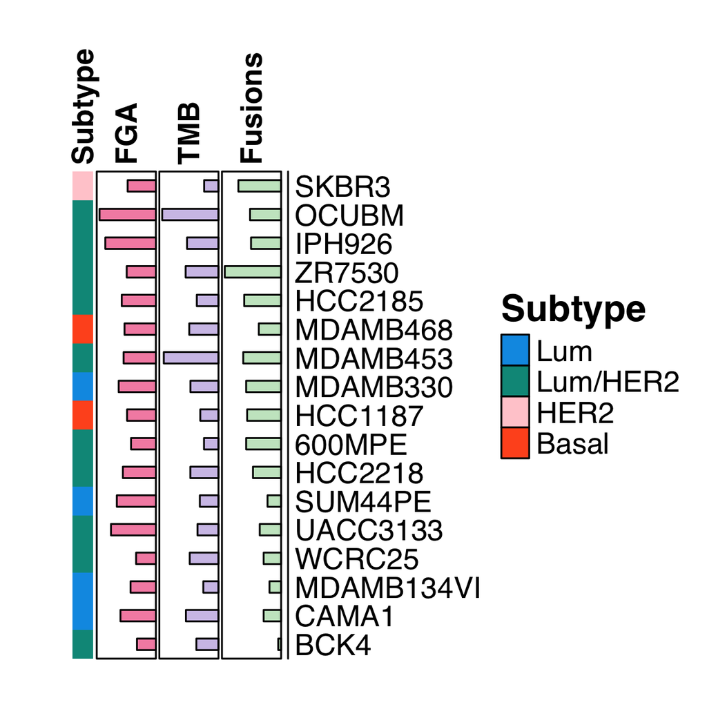

```r
fig3a_genomic_instability
```

### Figure 3A (right): ICLE SV Type Distribution

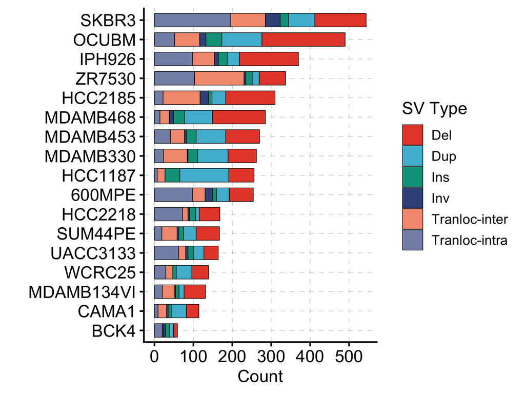

```r
ggsave(file.path(DIRS$results_sub$ogm, "Fig3A_right_SV_Distribution.pdf"), fig3a_sv_distribution, width = 6, height = 5)
fig3a_sv_distribution
```

### Figure 3B: Chromosomal Topography of Translocation Breakpoints

```r
pdf(file.path(DIRS$results_sub$ogm, "Fig3B_Translocation_Distribution.pdf"), width = 6.5, height = 5)
  draw(fig3b_transloc_breakpoints_ht, merge_legends = TRUE)
dev.off()
```

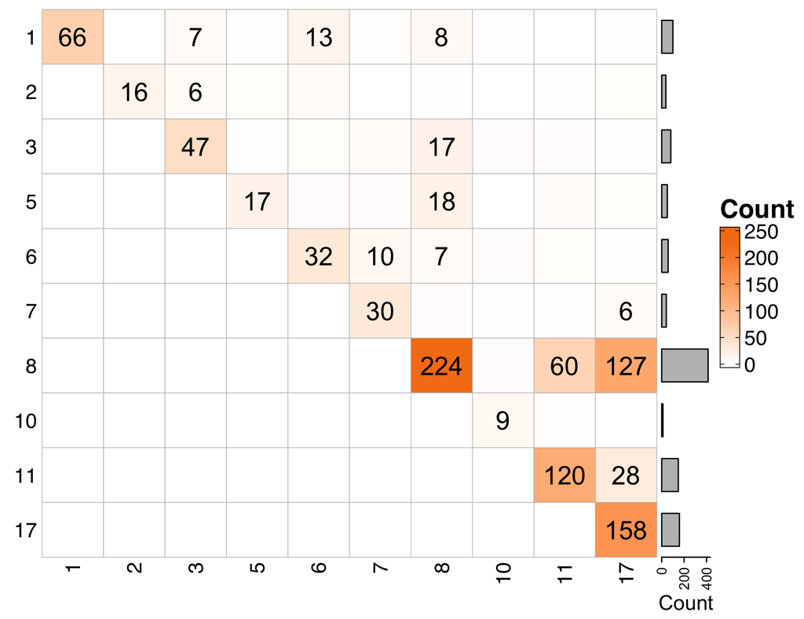

```r
fig3b_transloc_breakpoints_ht
```

### Figure 3C: Chromothripsis Landscape

Heatmap of chromothripsis events identified by ShatterSeek (Cortés-Ciriano et al. 2020) in ICLE cell lines. ShatterSeek integrates OGM SV and CNV data to detect chromosomes with hallmarks of chromothripsis (clustered oscillating CN states with co-localised SVs). Rows = chromosomes; columns = ICLE cell lines; tile colour encodes chromothripsis classification (high-confidence, low-confidence, absent). Full results saved to `SupTable11_shatterseek_chromothripsis_results.tsv`.

```r
write.table(shatterseek_outs$chromothripsis_df, file.path(DIRS$results_sub$ogm, "SupTable11_shatterseek_chromothripsis_results.tsv"), sep = "\t", col.names = NA)  # → Supplementary Table S11
pdf(file.path(DIRS$results_sub$ogm, "Fig3C_chromothripsis_heatmap.pdf"), width = 5, height = 5)
  draw(fig3c_thripsis_ht, merge_legends = TRUE)
dev.off()
```

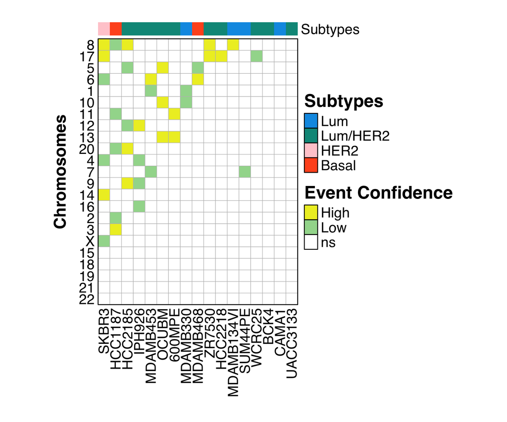

```r
draw(fig3c_thripsis_ht, merge_legends = TRUE)
```

### Figure 3D: OGM Circos Plots — BCK4, 600MPE, HCC2185, ZR7530

Interactive circos plots for four ICLE cell lines with high SV burden or clinically relevant rearrangements (BCK4, 600MPE, HCC2185, ZR7530), generated using interacCircos (Cui et al. 2021). Each plot shows genome-wide SV arcs overlaid on CN tracks. HTML widgets are exported to static PDFs using `webshot2` (requires Chromium; see `README.md`). Cell lines were selected to illustrate distinct OGM structural complexity patterns.

```r
# Load required libraries for HTML widget to PDF conversion
library(htmlwidgets)
library(webshot2)

# Save all four circos plots to PDF
message("Saving circos plots to PDF...")
```

```
## Saving circos plots to PDF...
```

```r
circos_bck4 <- save_circos_to_pdf(trk_bck4, "BCK4", DIRS$results_sub$ogm)
```

```
## ! Reconnecting to chrome process.
## ℹ All active sessions will be need to be respawned.

## file:////Users/oshah/Documents/ICLE/3-Results/Optical_Genome_Mapping/Fig3D_Circos_BCK4.html screenshot completed

##   ✓ Saved PDF: Fig3D_Circos_BCK4.pdf
```

```r
circos_600mpe <- save_circos_to_pdf(trk_600, "600MPE", DIRS$results_sub$ogm)
```

```
## file:////Users/oshah/Documents/ICLE/3-Results/Optical_Genome_Mapping/Fig3D_Circos_600MPE.html screenshot completed

##   ✓ Saved PDF: Fig3D_Circos_600MPE.pdf
```

```r
circos_hcc2185 <- save_circos_to_pdf(trk_hcc, "HCC2185", DIRS$results_sub$ogm)
```

```
## file:////Users/oshah/Documents/ICLE/3-Results/Optical_Genome_Mapping/Fig3D_Circos_HCC2185.html screenshot completed

##   ✓ Saved PDF: Fig3D_Circos_HCC2185.pdf
```

```r
circos_zr7530 <- save_circos_to_pdf(trk_zr, "ZR7530", DIRS$results_sub$ogm)
```

```
## file:////Users/oshah/Documents/ICLE/3-Results/Optical_Genome_Mapping/Fig3D_Circos_ZR7530.html screenshot completed

##   ✓ Saved PDF: Fig3D_Circos_ZR7530.pdf
```

```r
circos_bck4
```

[interactive chart not shown]

Fig 3D — BCK4 OGM circos

```r
circos_600mpe
```

[interactive chart not shown]

Fig 3D — 600MPE OGM circos

```r
circos_hcc2185
```

[interactive chart not shown]

Fig 3D — HCC2185 OGM circos

```r
circos_zr7530
```

[interactive chart not shown]

Fig 3D — ZR7530 OGM circos

### Figure 3E: Fusion Distribution (Patient Tumors vs Cell Lines)

Barplots comparing the distribution of OGM-detected gene fusions in ICLE cell lines against fusions reported in the TCGA TumorFusions dataset (Zhang et al. 2018). Fusions are classified by functional impact: Gain of Expression (GOE, z > 1) or Loss of Expression (LOE, z < −1) based on z-score normalizd RNA-seq expression of the fusion partner. Full fusion annotation table saved to `SupTable12_fusion_df.tsv`.

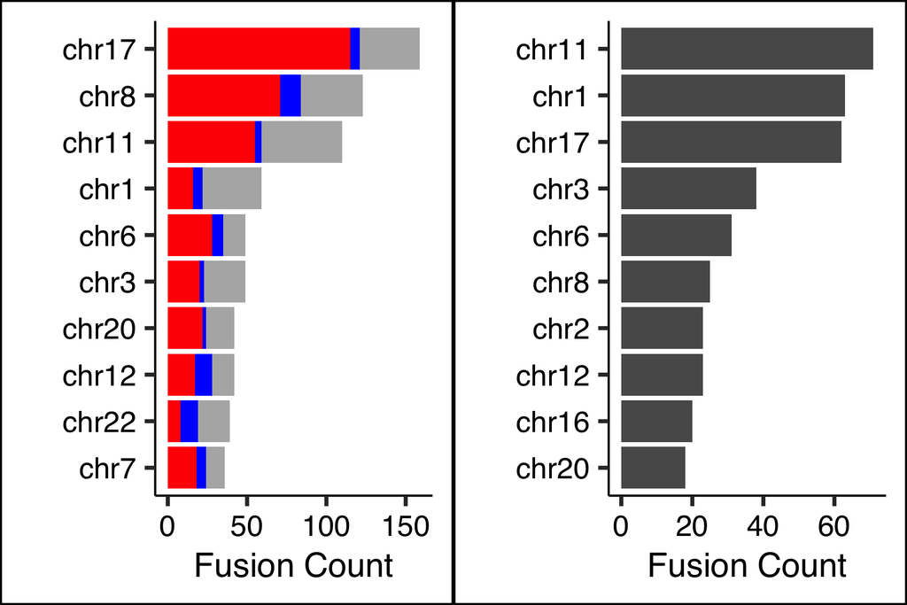

```r
# Save fusion distribution plots
ggsave(file.path(DIRS$results_sub$ogm, "Fig3E_right_FusionDistribution_ICLE.pdf"),
       fig3e_1, width = 3, height = 4)
ggsave(file.path(DIRS$results_sub$ogm, "Fig3E_right_FusionDistribution_PatientTumor.pdf"),
       fig3e_2+scale_x_continuous(breaks = c(0,25,50,75), limits = c(0,75)), width = 3, height = 4)

# Save fusion data table
write.table(fusions_df, file.path(DIRS$results_sub$ogm, "SupTable12_fusion_df.tsv"),  # → Supplementary Table S12
            quote = FALSE, sep = "\t", row.names = FALSE)

ggarrange(plotlist = list(fig3e_1, fig3e_2))
```

### Figure 3F: GOE and LOE Functional Fusions Circos

```r
pdf(file = file.path(DIRS$results_sub$ogm, "Fig3F_left_GOE_Fusions.pdf"), width = 7, height = 7)
fig3f_left_goe_fusions_circos
dev.off()
```

```r
pdf(file = file.path(DIRS$results_sub$ogm, "Fig3F_right_LOE_Fusions.pdf"), width = 7, height = 7)
fig3f_right_loe_fusions_circos
dev.off()
```

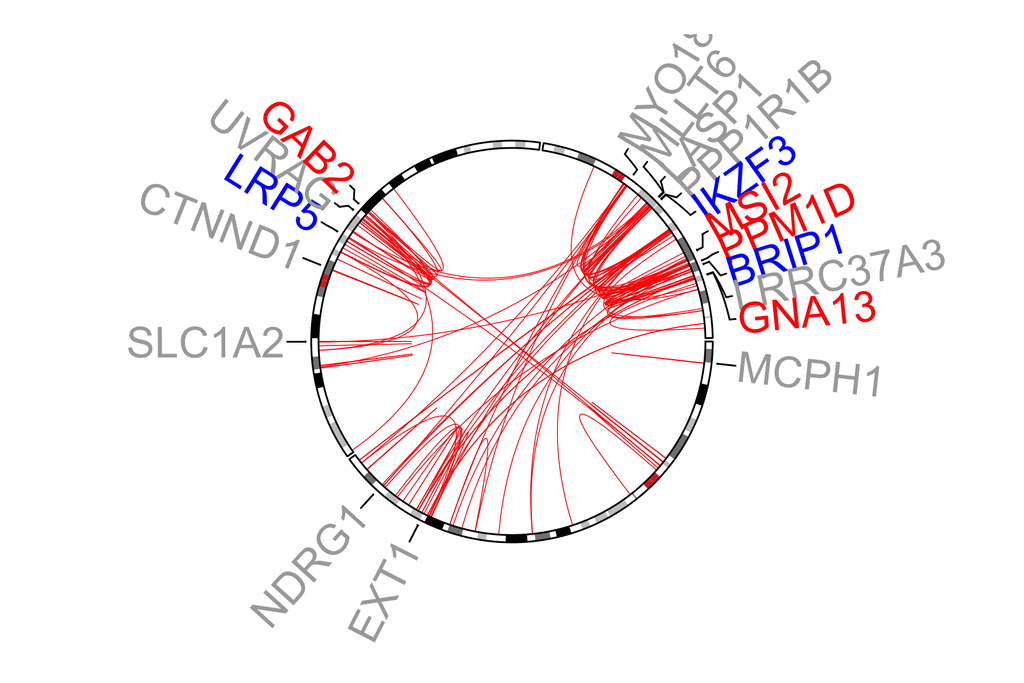

```r
plot.new()
print(fig3f_left_goe_fusions_circos)
```

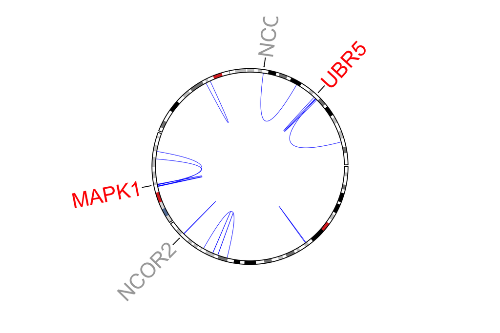

```r
plot.new()
print(fig3f_right_loe_fusions_circos)
```

### SupFig 8A: Mutation Count vs SV Count and SV Size

Scatter plot showign correlation between WES mutation count vs OGM SV count across ICLE cell lines.

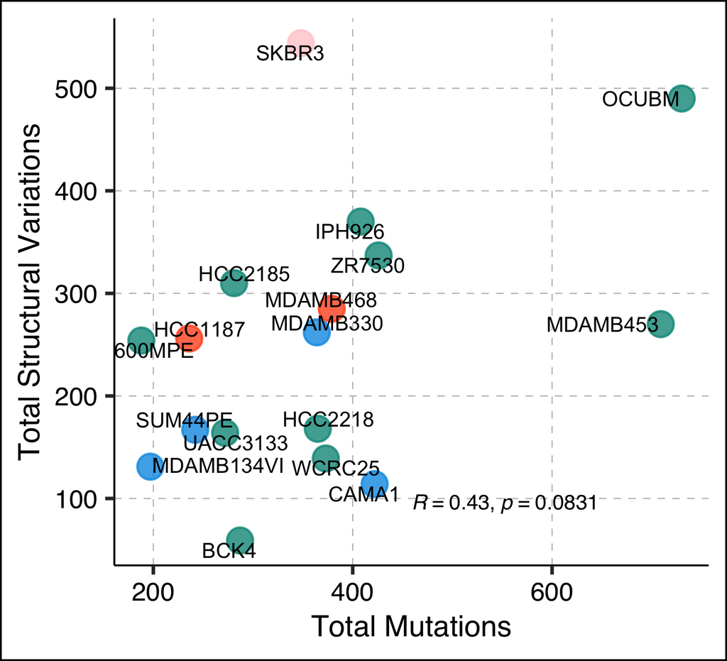

```r
ggsave(file.path(DIRS$results_sub$ogm, "SupFig8A_TMB_SV_Burden_Correlation.pdf"), SupFig8A, width = 5.5, height = 5)
write.table(sv_tmb_summary, file.path(DIRS$results_sub$ogm, "SupTable_SV_TMB_summary.tsv"), sep = "\t", quote = FALSE, row.names = FALSE)

SupFig8A
```

### SupFig 8B: TMB vs SV Burden (With and Without Outliers)

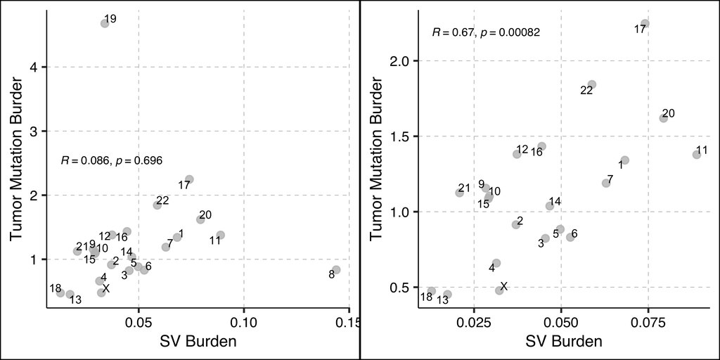

```r
ggsave(file.path(DIRS$results_sub$ogm, "SupFig8B_TMB_vs_SV_Burden_Correlation.pdf"), SupFig8B, width = 5.5, height = 5)
ggsave(file.path(DIRS$results_sub$ogm, "SupFig8B_TMB_vs_SV_Burden_Correlation_NoOutliers.pdf"), SupFig8B_no_outliers, width = 5.5, height = 5)
write.table(alt_count_chr, file.path(DIRS$results_sub$ogm, "SupTable_alt_count_per_chr.tsv"), sep = "\t", quote = FALSE, row.names = FALSE)

ggarrange(plotlist = list(SupFig8B, SupFig8B_no_outliers))
```